# redoil-lactate

Pierre Delobel

23/07/2021

# 1 Introduction

La quantification des gouttelettes lipidiques se fait au laboratoire avec un marquage à l’huile rouge (TECH-45 red oil o). Mais ce protocole encadre pour la visualisation et pas la quantification. Les marquages faits par Corentin selon le protocole du laboratoire ne marquent que les gouttelettes lipidiques donc ne permettent pas de rapporter les lipides au nombre de cellules.Cette information pourrait être estimée en utilisant un co-marquage avec un colorant nucléaire qui permettrait de rapporter la distribution des lipides à une quantité de cellules. Il a été estimé que la quantité de cellules était identique entre les deux conditions testées ici : avec ou sans lactate.

Une macro a été développée sous ImageJ afin de réaliser une quantification automatique de la répartition des gouttelettes de lipides.

# 2 logiciels

- Fiji/ImageJ (Schindelin et al. (2012), Schneider, Rasband, et Eliceiri (2012), Rueden et al. (2017)) et les plugings BIO-FORMATS (Linkert et al. (2010)) pour l’importation des données,
- RMarkdown (Xie, Allaire, et Grolemund (2018)} avec le logiciel RStudio (RStudio Team (2018))

# 3 Analyse

## 3.1 Basic

Une étape a été ajoutée par rapport aux analyse précédente pour la mise à l’échelle des images du microscope Ouverture des images avec ImageJ avec *split chanel*. Soustraction *rouge - vert* (C1-C3) car le ratio signal bruit est le plus intéressant. La soustraction se fait avec les images direct 16bit. L’option 32bit floating a été retirée pour écraser les zones sans marquage, afin d’avoir une meilleur gamme dynamique du signal. La conversion en 8bit est réalisée ensuite. L’analyse des particules peut se faire avec *Cookbook>Particules Analysis>Nucleus Counter*. Les options semblant le mieux fonctionner sont size : 10-1000000 ; Treshold Method : Adaptative (Base threshod = Otsu value ; Mask diameter :3 ; Local weight : 5.0); Smooth Meth : Median 3x3 ; soustraction du bruit de fond; Watershed filter ; Add Particuls ti ROI manager ; Show summary

Correction pour des question de conservation d’échelle changer Adaptative en Otsu !

# 4 Récupération des données d’ImageJ

```r
cibles<- read.table("data2-lactate/cibles.csv", sep="\t",dec=".",colClasses="factor",header = T)
summary(cibles)
```

```
##                    dossier          Fichier.image puit    diaphragme
##  210721-huile-rouge-x20:12   B3-ctrl-10.zvi: 1    B3:16   DIC:33
##  210721-huile-rouge-x40:21   B3-ctrl-11.zvi: 1    B6:17
##                              B3-ctrl-12.zvi: 1
##                              B3-ctrl-13.zvi: 1
##                              B3-ctrl-15.zvi: 1
##                              B3-ctrl-16.zvi: 1
##                              (Other)       :27
##      champ     condition  objectif
##  1      :4   ctrl   :16   20x:12
##  2      :4   lactate:17   40x:21
##  3      :4
##  4      :4
##  5      :4
##  6      :4
##  (Other):9
```

```r
cibles$Results.csv<-paste(cibles$dossier,"macro-red-v5",gsub(pattern = ".zvi","-Results.csv",cibles$Fichier.image ),sep="/")
cibles$code<-paste(cibles$dossier,"macro-red-v5",gsub(pattern = ".zvi","",cibles$Fichier.image ),sep="_")
cibles$mediane<-0 ## mediane de AREA  des taches red oil
cibles$nombre<-0 ## nombre de taches red oil du champ
cibles$moyenne<-0 ## moyenne de AREA des taches red oil
cibles$SD<-0 ## SD de moyenne red oil du champ
cibles$SEM<-0 ## SD de moyenne red oil du champ

cibles$Feret<-0 ## mediane diametre de Feret des taches red oil du champ
cibles$MinFeret<-0 ## mediane diametre de Feret minimal des taches red oil du champ

data.redoil<-data.frame()

for (i in 1:dim(cibles)[1]){
  titi<-read.table(paste("data2-lactate/",as.character(cibles$Results.csv[i]),sep=""), sep=",",dec=".",header = T)

  cibles$mediane[i]<-median(titi$Area, na.rm = TRUE)
  cibles$moyenne[i]<-mean(titi$Area, na.rm = TRUE)
  cibles$SD[i]<-sd(titi$Area, na.rm = TRUE)
  cibles$nombre[i]<-dim(titi)[1]
  cibles$SEM[i]<-cibles$SD[i]/sqrt(cibles$nombre[i])
  cibles$Feret[i]<-median(titi$Feret, na.rm = TRUE)
  cibles$MinFeret[i]<-median(titi$MinFeret, na.rm = TRUE)

  titi<-cbind(cibles[i,],titi[,-1])
  data.redoil<-rbind.data.frame(data.redoil,titi)


}
```

[output not shown]

[output cut: 43 more lines]

[output not shown]

```r
data.analyse<-subset(data.redoil,diaphragme=="DIC")
summary(cibles)
```

```
##                    dossier          Fichier.image puit    diaphragme
##  210721-huile-rouge-x20:12   B3-ctrl-10.zvi: 1    B3:16   DIC:33
##  210721-huile-rouge-x40:21   B3-ctrl-11.zvi: 1    B6:17
##                              B3-ctrl-12.zvi: 1
##                              B3-ctrl-13.zvi: 1
##                              B3-ctrl-15.zvi: 1
##                              B3-ctrl-16.zvi: 1
##                              (Other)       :27
##      champ     condition  objectif Results.csv            code
##  1      :4   ctrl   :16   20x:12   Length:33          Length:33
##  2      :4   lactate:17   40x:21   Class :character   Class :character
##  3      :4                         Mode  :character   Mode  :character
##  4      :4
##  5      :4
##  6      :4
##  (Other):9
##     mediane            nombre        moyenne              SD
##  Min.   :0.01000   Min.   :3097   Min.   :0.03674   Min.   :0.06944
##  1st Qu.:0.01000   1st Qu.:5711   1st Qu.:0.04253   1st Qu.:0.11694
##  Median :0.02000   Median :6074   Median :0.04777   Median :0.13326
##  Mean   :0.02909   Mean   :6135   Mean   :0.07929   Mean   :0.16604
##  3rd Qu.:0.05000   3rd Qu.:6627   3rd Qu.:0.10654   3rd Qu.:0.22453
##  Max.   :0.08000   Max.   :9735   Max.   :0.19467   Max.   :0.30893
##
##       SEM                Feret         MinFeret
##  Min.   :0.0008963   Min.   :0.15   Min.   :0.0900
##  1st Qu.:0.0014959   1st Qu.:0.17   1st Qu.:0.1100
##  Median :0.0018368   Median :0.19   Median :0.1300
##  Mean   :0.0021420   Mean   :0.24   Mean   :0.1579
##  3rd Qu.:0.0026970   3rd Qu.:0.31   3rd Qu.:0.2200
##  Max.   :0.0040274   Max.   :0.42   Max.   :0.2900
##
```

```r
write.table(cibles,file="data2-lactate/resultatsR.csv", row.names = FALSE,sep="\t",dec=".")
```

## 4.1 Représentation des données

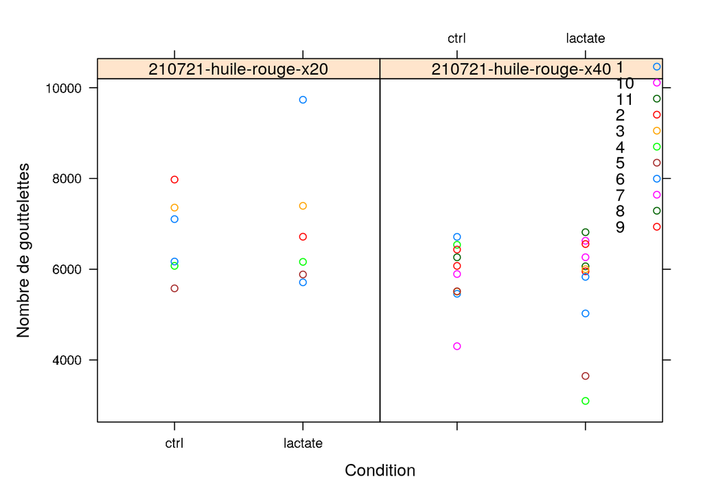

```r
xyplot(nombre~condition|dossier,groups=champ,data=cibles,auto.key =list(x = 0.9, y = 1.0),title=(""),xlab="Condition",ylab="Nombre de gouttelettes")
```

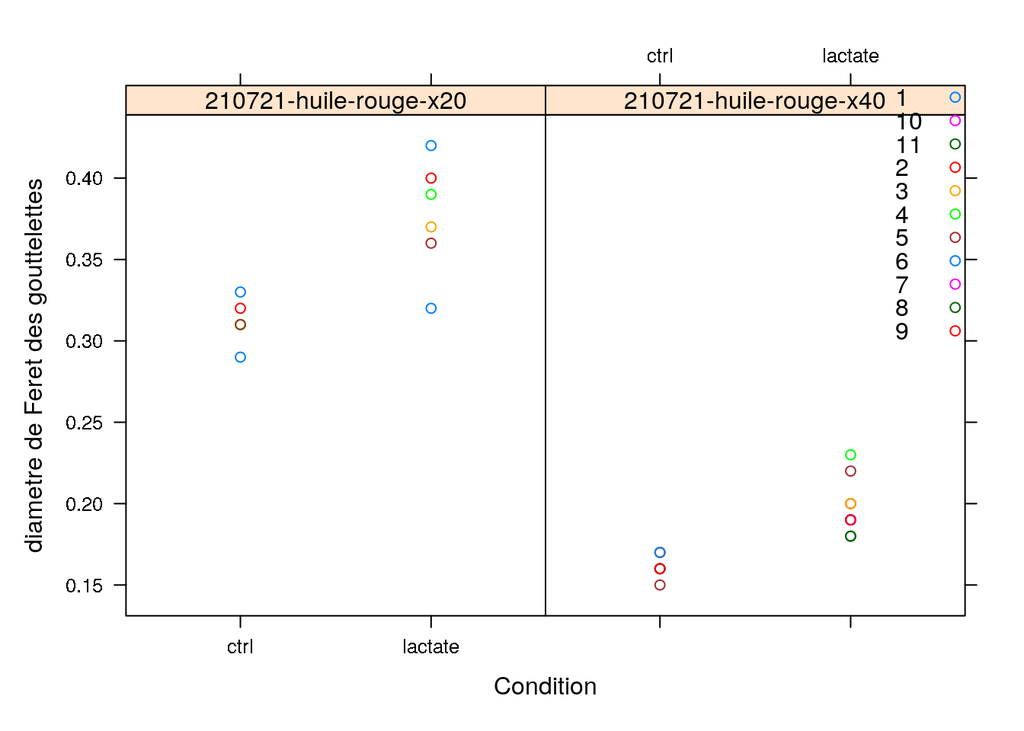

```r
xyplot(Feret~condition|dossier,groups=champ,data=cibles,auto.key =list(x = 0.9, y = 1.0),title=(""),xlab="Condition",ylab="diametre de Feret des gouttelettes")
```

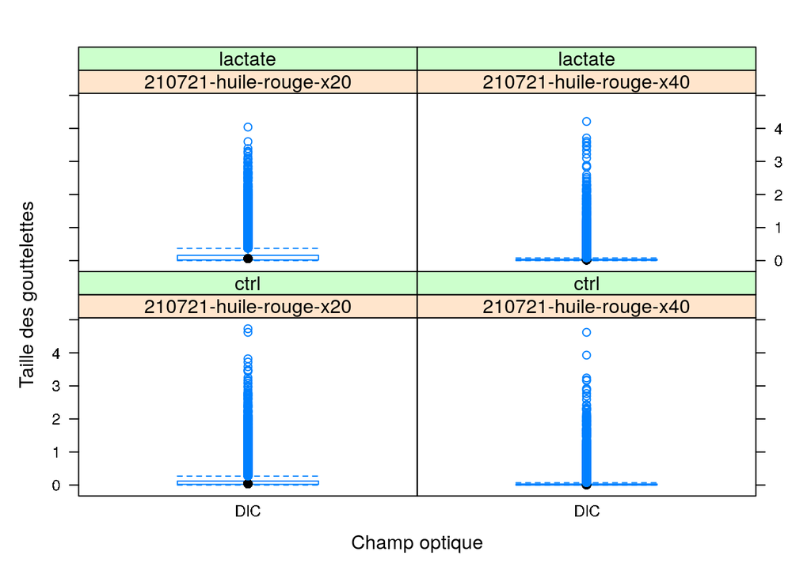

```r
bwplot(Area~diaphragme|dossier*condition,data=data.redoil,auto.key =list(x = 0.6, y = 0.9),title=(""),xlab="Champ optique",ylab="Taille des gouttelettes")
```

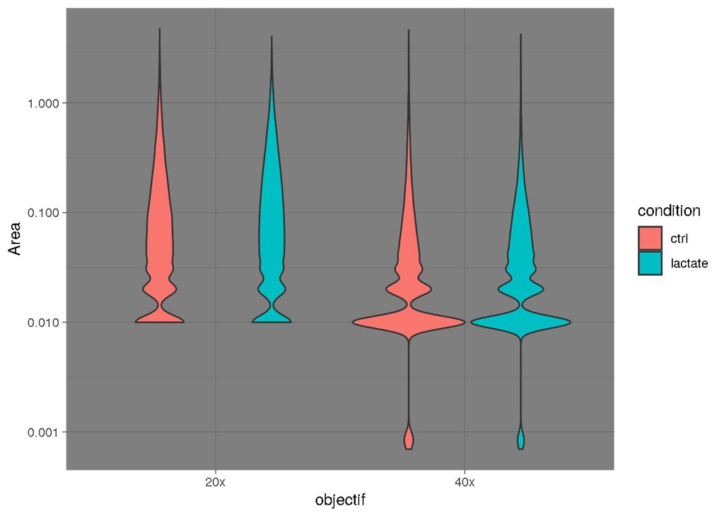

```r
ggplot(data.analyse, aes(x = objectif , y = Area,fill=condition)) +
    geom_violin()+ geom_violin() +theme_dark()+ scale_y_log10()
```

Il est intéressant de constater la similarité des distributions de taille, l’utilisation de l’objectif 40x ne permet que la récupération de toutes petites gouttelettes en plus que l’observation au 20x . Les profils de taille représentent des grouppement de taille bien marqués, seulement visible en échelle log